# 計量経済学のためのTeX数式チートシート

R Markdownで数式を書くための基本

専門英語講読A（小林流基）

2026-04-15

# 1 はじめに

このドキュメントは、R Markdownで計量経済学の数式を書くために必要なTeX記法をまとめたものです。 このファイル自体が `.Rmd` ファイルなので、ソースコードを見ながら「どう書けばどう表示されるか」を確認できます。

> ★ 数式の表示がおかしいとき：RStudio のプレビュー画面では `\hat` や `\bar` の位置がずれたり、表の中の数式がコードのように見えることがあります。これは RStudio 内蔵ビューアーの既知の問題です。**Knit した HTML ファイルをブラウザ（Chrome 等）で直接開けば正しく表示されます。**

## 1.1 数式の書き方（基本）

R Markdownでは、TeX（LaTeX）の記法を使って数式を挿入できます。

- **インライン数式**：文中に数式を埋め込むには、`$` で囲みます。
  - 例：`$Y = \beta_0 + \beta_1 X$` → $Y = \beta_0 + \beta_1 X$
- **別行立て数式**：独立した行に数式を表示するには、`$$` で囲みます。

```
$$
Y_i = \beta_0 + \beta_1 X_i + \varepsilon_i
$$
```

$$Y_i = \beta_0 + \beta_1 X_i + \varepsilon_i$$

# 2 ギリシャ文字

計量経済学でよく使うギリシャ文字の一覧です。

| 表示 | 記法 | 用途の例 |
| --- | --- | --- |
| $\alpha$ | `\alpha` | 有意水準、定数 |
| $\beta$ | `\beta` | 回帰係数 |
| $\gamma$ | `\gamma` | パラメータ |
| $\delta$ | `\delta` | 差分、処置効果 |
| $\varepsilon$ | `\varepsilon` | 誤差項 |
| $\epsilon$ | `\epsilon` | 誤差項（別の書体） |
| $\eta$ | `\eta` | 弾力性 |
| $\theta$ | `\theta` | パラメータ |
| $\lambda$ | `\lambda` | ラグランジュ乗数 |
| $\mu$ | `\mu` | 平均、期待値 |
| $\nu$ | `\nu` | 自由度 |
| $\pi$ | `\pi` | 確率、操作変数の第1段階係数 |
| $\rho$ | `\rho` | 相関係数、自己相関 |
| $\sigma$ | `\sigma` | 標準偏差 |
| $\tau$ | `\tau` | 処置効果 |
| $\phi$ | `\phi` | 標準正規分布の密度関数 |
| $\chi$ | `\chi` | カイ二乗分布 |
| $\omega$ | `\omega` | 重み |

**大文字のギリシャ文字**（先頭を大文字にする）：

| 表示 | 記法 | 用途の例 |
| --- | --- | --- |
| $\Delta$ | `\Delta` | 変化量（差分） |
| $\Sigma$ | `\Sigma` | 総和、分散共分散行列 |
| $\Phi$ | `\Phi` | 標準正規分布の累積分布関数 |
| $\Omega$ | `\Omega` | 分散共分散行列 |

# 3 上付き・下付き文字

| 表示 | 記法 | 説明 |
| --- | --- | --- |
| $X^2$ | `X^2` | 上付き（1文字） |
| $X^{10}$ | `X^{10}` | 上付き（2文字以上は `{}` で囲む） |
| $X_i$ | `X_i` | 下付き（1文字） |
| $X_{it}$ | `X_{it}` | 下付き（2文字以上は `{}` で囲む） |
| $\beta_1$ | `\beta_1` | 回帰係数 |
| $\hat{\beta}_1$ | `\hat{\beta}_1` | OLS推定量 |
| $X_i^2$ | `X_i^2` | 上付きと下付きの組み合わせ |

# 4 回帰モデルの表記

## 4.1 単回帰モデル

$$Y_i = \beta_0 + \beta_1 X_i + \varepsilon_i$$

```
$$
Y_i = \beta_0 + \beta_1 X_i + \varepsilon_i
$$
```

## 4.2 重回帰モデル

$$Y_i = \beta_0 + \beta_1 X_{1i} + \beta_2 X_{2i} + \cdots + \beta_k
X_{ki} + \varepsilon_i$$

```
$$
Y_i = \beta_0 + \beta_1 X_{1i} + \beta_2 X_{2i} + \cdots + \beta_k X_{ki} + \varepsilon_i
$$
```

## 4.3 推定値（ハット表記）

$$\hat{Y}_i = \hat{\beta}_0 + \hat{\beta}_1 X_i$$

```
$$
\hat{Y}_i = \hat{\beta}_0 + \hat{\beta}_1 X_i
$$
```

## 4.4 残差

$$\hat{u}_i = Y_i - \hat{Y}_i$$

## 4.5 対数モデル

回帰分析では、変数を対数変換することがよくあります。`\log` または `\ln` を使います。

$$\log(Y_i) = \beta_0 + \beta_1 \log(X_i) + \varepsilon_i$$

```
$$
\log(Y_i) = \beta_0 + \beta_1 \log(X_i) + \varepsilon_i
$$
```

| モデル | 式 | $\beta_1$ の解釈 |
| --- | --- | --- |
| Level-Level | $Y = \beta_0 + \beta_1 X$ | $X$ が1単位増 → $Y$ が $\beta_1$ 増 |
| Log-Level | $\log(Y) = \beta_0 + \beta_1 X$ | $X$ が1単位増 → $Y$ が約 $100\beta_1$% 増 |
| Level-Log | $Y = \beta_0 + \beta_1 \log(X)$ | $X$ が1%増 → $Y$ が約 $\beta_1/100$ 増 |
| Log-Log | $\log(Y) = \beta_0 + \beta_1 \log(X)$ | $X$ が1%増 → $Y$ が約 $\beta_1$% 増 |

## 4.6 行列表記

$$\mathbf{Y} = \mathbf{X} \boldsymbol{\beta} + \boldsymbol{\varepsilon}$$

```
$$
\mathbf{Y} = \mathbf{X} \boldsymbol{\beta} + \boldsymbol{\varepsilon}
$$
```

ベクトルや行列の太字には `\mathbf{}` （ローマン体）または `\boldsymbol{}` （ギリシャ文字）を使います。

# 5 分数・ルート・ドット

| 表示 | 記法 | 説明 |
| --- | --- | --- |
| $\frac{a}{b}$ | `\frac{a}{b}` | 分数 |
| $\frac{\partial Y}{\partial X}$ | `\frac{\partial Y}{\partial X}` | 偏微分 |
| $\sqrt{n}$ | `\sqrt{n}` | 平方根 |
| $\cdots$ | `\cdots` | 横の省略記号 |
| $\vdots$ | `\vdots` | 縦の省略記号 |
| $\bar{X}$ | `\bar{X}` | 標本平均 |
| $\tilde{\beta}$ | `\tilde{\beta}` | チルダ |
| $\overline{Y}$ | `\overline{Y}` | 上線（長め） |

# 6 総和・積分

$$\bar{X} = \frac{1}{n} \sum_{i=1}^{n} X_i$$

```
$$
\bar{X} = \frac{1}{n} \sum_{i=1}^{n} X_i
$$
```

$$\hat{\beta}_1 = \frac{\sum_{i=1}^{n}(X_i - \bar{X})(Y_i -
\bar{Y})}{\sum_{i=1}^{n}(X_i - \bar{X})^2}$$

```
$$
\hat{\beta}_1 = \frac{\sum_{i=1}^{n}(X_i - \bar{X})(Y_i - \bar{Y})}{\sum_{i=1}^{n}(X_i - \bar{X})^2}
$$
```

積分は `\int` を使います。上限・下限は総和と同じく `^` と `_` で指定します。

$$\widehat{\delta}_{ATE} = \int \left( E[Y \mid X, D=1] - E[Y \mid X, D=0]
\right) d\Pr(X)$$

```
$$
\widehat{\delta}_{ATE} = \int \left( E[Y \mid X, D=1] - E[Y \mid X, D=0] \right) d\Pr(X)
$$
```

定積分の例：

$$\int_0^1 f(x) \, dx$$

```
$$
\int_0^1 f(x) \, dx
$$
```

`\,` は積分記号と $dx$ の間に小さなスペースを入れるための記法です。

# 7 期待値・分散・共分散

| 表示 | 記法 |
| --- | --- |
| $E[Y]$ | `E[Y]` |
| $E[Y \mid X]$ | `E[Y \mid X]` |
| $\text{Var}(X)$ | `\text{Var}(X)` |
| $\text{Cov}(X, Y)$ | `\text{Cov}(X, Y)` |
| $\text{Corr}(X, Y)$ | `\text{Corr}(X, Y)` |
| $\text{plim}$ | `\text{plim}` |

`\text{}` を使うと、数式中でも立体（ローマン体）で表示されます。 これを使わないと $Var(X)$ のように斜体になり、変数の積のように見えてしまいます。

# 8 等号・不等号・近似

| 表示 | 記法 | 意味 |
| --- | --- | --- |
| $=$ | `=` | 等号 |
| $\neq$ | `\neq` | 不等号 |
| $\approx$ | `\approx` | 近似 |
| $\equiv$ | `\equiv` | 定義、恒等式 |
| $\leq$ | `\leq` | 以下 |
| $\geq$ | `\geq` | 以上 |
| $<$ | `<` | 未満 |
| $>$ | `>` | 超過 |
| $\sim$ | `\sim` | 分布に従う |
| $\propto$ | `\propto` | 比例する |

# 9 矢印（DAG・因果ダイアグラム）

因果ダイアグラム（DAG）のパスを文中で表記するときに使います。

| 表示 | 記法 | 用途 |
| --- | --- | --- |
| $\rightarrow$ | `\rightarrow` | 因果の方向（$X \rightarrow Y$） |
| $\leftarrow$ | `\leftarrow` | バックドアパス（$X \leftarrow Z \rightarrow Y$） |

例：バックドアパスの表記

$$D \leftarrow Z \rightarrow Y$$

```
$$
D \leftarrow Z \rightarrow Y
$$
```

# 10 確率・分布

正規分布に従う：

$$\varepsilon_i \sim N(0, \sigma^2)$$

```
$$
\varepsilon_i \sim N(0, \sigma^2)
$$
```

漸近正規性：

$$\sqrt{n}(\hat{\beta} - \beta) \xrightarrow{d} N(0, V)$$

```
$$
\sqrt{n}(\hat{\beta} - \beta) \xrightarrow{d} N(0, V)
$$
```

確率収束：

$$\hat{\beta} \xrightarrow{p} \beta$$

```
$$
\hat{\beta} \xrightarrow{p} \beta
$$
```

# 11 因果推論の表記

## 11.1 ポテンシャルアウトカム

$$Y_i = D_i \cdot Y_i(1) + (1 - D_i) \cdot Y_i(0)$$

## 11.2 処置効果

| 表示 | 記法 | 意味 |
| --- | --- | --- |
| $\text{ATE}$ | `\text{ATE}` | 平均処置効果 |
| $\text{ATT}$ | `\text{ATT}` | 処置群の平均処置効果 |
| $\text{LATE}$ | `\text{LATE}` | 局所平均処置効果 |

$$\text{ATE} = E[Y_i(1) - Y_i(0)]$$

$$\text{ATT} = E[Y_i(1) - Y_i(0) \mid D_i = 1]$$

## 11.3 条件付き独立性（CIA）

$$\{Y_i(0), Y_i(1)\} \perp D_i \mid X_i$$

```
$$
\{Y_i(0), Y_i(1)\} \perp D_i \mid X_i
$$
```

`\perp` は独立を表す記号（$\perp$）です。

二重の独立記号（$\perp\!\!\!\perp$）を使うこともあります：

$$\{Y_i(0), Y_i(1)\} \perp\!\!\!\perp D_i \mid X_i$$

```
$$
\{Y_i(0), Y_i(1)\} \perp\!\!\!\perp D_i \mid X_i
$$
```

`\perp\!\!\!\perp` で二重の独立記号になります。`\!` は負のスペース（文字を詰める）です。

# 12 括弧の調整

数式が大きい場合、`\left` と `\right` を使うと括弧のサイズが自動調整されます。

**調整なし**：

$$(\frac{1}{n} \sum_{i=1}^{n} X_i)$$

**調整あり**（`\left(` … `\right)` を使用）：

$$\left(\frac{1}{n} \sum_{i=1}^{n} X_i\right)$$

```
$$
\left(\frac{1}{n} \sum_{i=1}^{n} X_i\right)
$$
```

絶対値も `\left|` と `\right|` で自動調整できます：

$$\left| \bar{X} - \mu \right|$$

```
$$
\left| \bar{X} - \mu \right|
$$
```

# 13 複数行の数式（aligned 環境）

等号の位置を揃えて複数行に書くには、`aligned` 環境を使います。

$$\begin{aligned}
\hat{\beta}_1 &= \frac{\text{Cov}(X, Y)}{\text{Var}(X)} \\
&= \frac{\sum_{i=1}^{n}(X_i - \bar{X})(Y_i -
\bar{Y})}{\sum_{i=1}^{n}(X_i - \bar{X})^2}
\end{aligned}$$

```
$$
\begin{aligned}
\hat{\beta}_1 &= \frac{\text{Cov}(X, Y)}{\text{Var}(X)} \\
&= \frac{\sum_{i=1}^{n}(X_i - \bar{X})(Y_i - \bar{Y})}{\sum_{i=1}^{n}(X_i - \bar{X})^2}
\end{aligned}
$$
```

`&` は揃える位置、`\\` は改行を意味します。

# 14 場合分け（cases 環境）

$$D_i = \begin{cases}
1 & \text{if treated} \\
0 & \text{if control}
\end{cases}$$

```
$$
D_i = \begin{cases}
1 & \text{if treated} \\
0 & \text{if control}
\end{cases}
$$
```

# 15 Rコードチャンクの書き方

R Markdownでは、以下のようにRのコードを埋め込むことができます。

````
```{r}
# ここにRコードを書く
x <- rnorm(100)
mean(x)
```
````

実行例：

```r
# 標本平均を計算する
set.seed(42)
x <- rnorm(100, mean = 5, sd = 2)
mean(x)
```

```
## [1] 5.06503
```

グラフも表示できます：

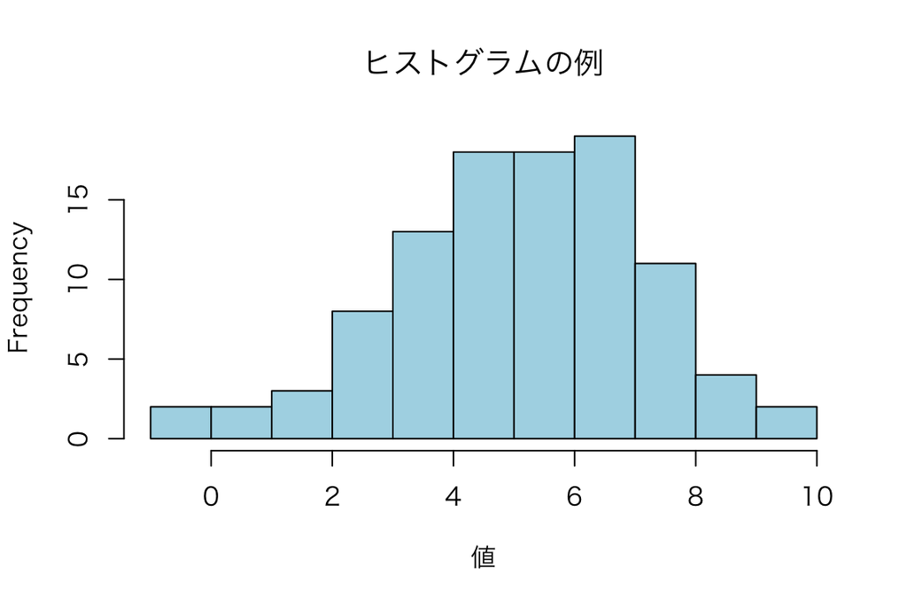

```r
par(family = my_font)
hist(x, main = "ヒストグラムの例", xlab = "値", col = "lightblue")
```

# 16 まとめ：よく使う記法 早見表

| やりたいことの例 | 記法 | 表示 |
| --- | --- | --- |
| 回帰係数 | `\beta_1` | $\beta_1$ |
| 推定値 | `\hat{\beta}_1` | $\hat{\beta}_1$ |
| 誤差項 | `\varepsilon_i` | $\varepsilon_i$ |
| 標本平均 | `\bar{X}` | $\bar{X}$ |
| 分数 | `\frac{a}{b}` | $\frac{a}{b}$ |
| 総和 | `\sum_{i=1}^{n}` | $\sum_{i=1}^{n}$ |
| 期待値 | `E[Y \mid X]` | $E[Y \mid X]$ |
| 分散 | `\text{Var}(X)` | $\text{Var}(X)$ |
| 正規分布 | `N(\mu, \sigma^2)` | $N(\mu, \sigma^2)$ |
| 分布に従う | `\sim` | $\sim$ |
| 独立 | `\perp` | $\perp$ |
| 括弧調整 | `\left( \right)` | $\left(\frac{a}{b}\right)$ |
| 太字ベクトル | `\mathbf{X}` | $\mathbf{X}$ |
| 偏微分 | `\frac{\partial Y}{\partial X}` | $\frac{\partial Y}{\partial X}$ |
| 因果の矢印 | `\rightarrow` | $\rightarrow$ |
| バックドア | `\leftarrow` | $\leftarrow$ |
| 対数 | `\log(Y)` | $\log(Y)$ |
| 独立（二重） | `\perp\!\!\!\perp` | $\perp\!\!\!\perp$ |
| 積分 | `\int_0^1 f(x) \, dx` | $\int_0^1 f(x) \, dx$ |
| 絶対値 | `\left\| x \right\|` | $\left\| x \right\|$ |

# 17 参考情報

- **R Markdown 公式ドキュメント**: rmarkdown.rstudio.com
- **R Markdown: The Definitive Guide**（Xie, Allaire, Grolemund）: [bookdown.org/yihui/rmarkdown](https://bookdown.org/yihui/rmarkdown/)
- **R Markdown 入門**（前田和寛 [@kazutan]）: kazutan.github.io/kazutanR/Rmd_intro.html
- **R Markdown 入門**（宋財泫 [Song Jaehyun]）: www.jaysong.net/tutorial/R/rmarkdown_intro.html
- **私たちのR**（宋財泫・矢内勇生）: [www.jaysong.net/RBook](https://www.jaysong.net/RBook/) — R 全般の日本語入門書。Quarto の解説もあり